# Ligand Activity Regressions: Inflammation Atlas

EYW

2026-08-17

```r
knitr::opts_chunk$set(echo = TRUE)
source("regression_helpers.R")
```

# Goal

Test which SIG13 ligand activities differ between each inflammatory disease and healthy controls in the Inflammation Atlas CD4 T cells, using the activity scores from `02_score_disease_datasets.py`.

Three models, all contrasting each disease against `healthy`:

1. **Disease** – one value per patient, across all CD4 T cells
2. **Naive vs non-naive** (`Level1`, Tregs excluded) – disease x celltype
3. **Fine celltype** (`Level2`) – disease x celltype

The earlier analysis mixed the two parameterizations – `binned_age` in models 1-2, continuous age in model 3 – so those models were fit on different sample sets without that being visible.

# Import

```r
ATLAS_KEYS <- c("studyID", "sampleID", "patientID", "disease", "sex", "age",
                "binned_age", "chemistry", "diseaseGroup")

atlas <- load_activity_scores("inflammation_atlas", ATLAS_KEYS)

# celltype tables: the celltype is the last key, renamed to `celltype` throughout
atlas_level1 <- load_activity_scores("inflammation_atlas_celltypeLevel1_noTregs",
                                     c(ATLAS_KEYS, "Level1")) %>%
  rename(celltype = Level1)
atlas_level2 <- load_activity_scores("inflammation_atlas_celltypeLevel2",
                                     c(ATLAS_KEYS, "Level2")) %>%
  rename(celltype = Level2)

activities <- activity_names()
cat(nrow(atlas), "samples,", length(activities), "ligand activities\n")
```

```
## 816 samples, 38 ligand activities
```

```r
#' Every model adjusts for binned age, so samples with no binned age (stored
#' as the string "nan") cannot contribute. They are dropped here explicitly, with a
#' count, rather than silently by `lm`'s na.omit.
drop_missing_age <- function(df, label) {
  df <- mutate(df, age = as.numeric(age))
  cat(sprintf("%-22s dropping %3d of %4d samples with no recorded binned age\n",
              label, sum(is.na(df$binned_age)), nrow(df)))
  df %>%
    filter(!is.na(binned_age)) %>%
    # a disease can lose every sample (see the QC table below); dropping the empty
    # factor level keeps emmeans from building contrasts it cannot estimate
    droplevels()
}
```

```r
# one patient per row? (the disease model averages within patient regardless)
cat(nrow(atlas), "samples from", n_distinct(atlas$patientID), "patients\n")
```

```
## 816 samples from 816 patients
```

```r
atlas %>% count(disease, name = "samples") %>% arrange(desc(samples))
```

```
## # A tibble: 20 × 2
##    disease   samples
##    <chr>       <int>
##  1 healthy       270
##  2 SLE           142
##  3 COVID         117
##  4 RA             38
##  5 sepsis         34
##  6 PS             26
##  7 PSA            26
##  8 UC             22
##  9 CD             21
## 10 HNSCC          21
## 11 HBV            15
## 12 CRC            14
## 13 COPD           12
## 14 asthma         12
## 15 flu            11
## 16 NPC            10
## 17 cirrhosis       8
## 18 BRCA            6
## 19 HIV             6
## 20 MS              5
```

# Covariate QC

Confirm no covariate tracks disease so strongly that it cannot be adjusted for.

Note that in some cases binned_age is provided but age is not. Hence in the bottom plot `flu` is recorded without age for all 11 of its patients, but binned_age is present.

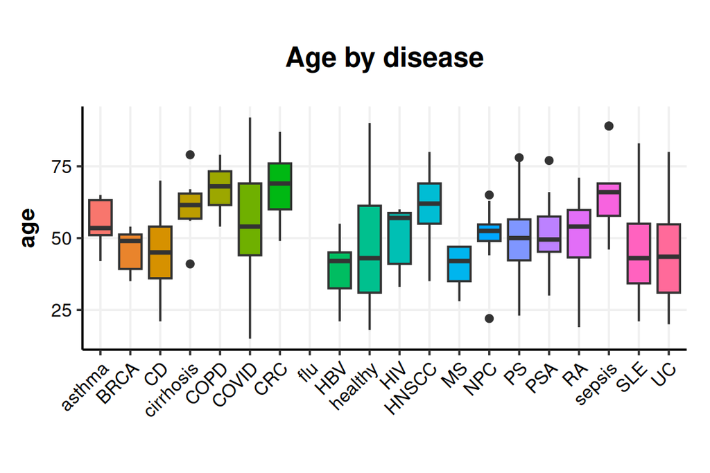

```r
atlas %>%
  mutate(age = as.numeric(age)) %>%
  ggplot(aes(x = disease, y = age, fill = disease)) +
  geom_boxplot(show.legend = FALSE, na.rm = TRUE) +
  theme(axis.text.x = element_text(angle = 45, hjust = 1)) +
  labs(title = "Age by disease", x = "", y = "age")
```

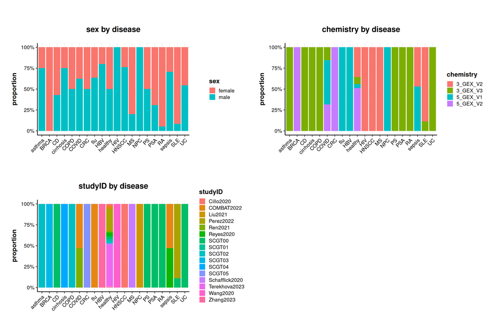

```r
map(c("sex", "chemistry", "studyID"), function(variable) {
  ggplot(atlas, aes(x = disease, fill = !!sym(variable))) +
    geom_bar(position = "fill") +
    scale_y_continuous(labels = scales::percent) +
    theme(axis.text.x = element_text(angle = 45, hjust = 1)) +
    labs(title = paste(variable, "by disease"), x = "", y = "proportion")
}) %>% wrap_plots(ncol = 2)
```

The healthy controls are reasonably balanced; `studyID` is confounded with disease by construction (each study contributes specific diseases) and so is not modelled.

# Disease associations

One row per patient (averaging any repeat samples), each disease vs `healthy`.

```r
data_disease <- atlas %>%
  group_by(studyID, patientID, disease, sex, age, binned_age, chemistry, diseaseGroup) %>%
  summarise(across(all_of(activities), mean), .groups = "drop") %>%
  mutate(across(c(disease, sex, chemistry, studyID), factor)) %>%
  drop_missing_age("disease")
```

```
## disease                dropping   0 of  816 samples with no recorded binned age
```

```r
res_disease <- fit_and_save(
  data_disease,
  rhs = "disease + sex + binned_age + chemistry",
  emm = ~ disease,
  contrast_args = list(method = "trt.vs.ctrl", ref = "healthy"),
  name = "inflammation_atlas_disease"
)
```

```
## inflammation_atlas_disease: 722 contrast x activity rows, 379 with padj < 0.1
```

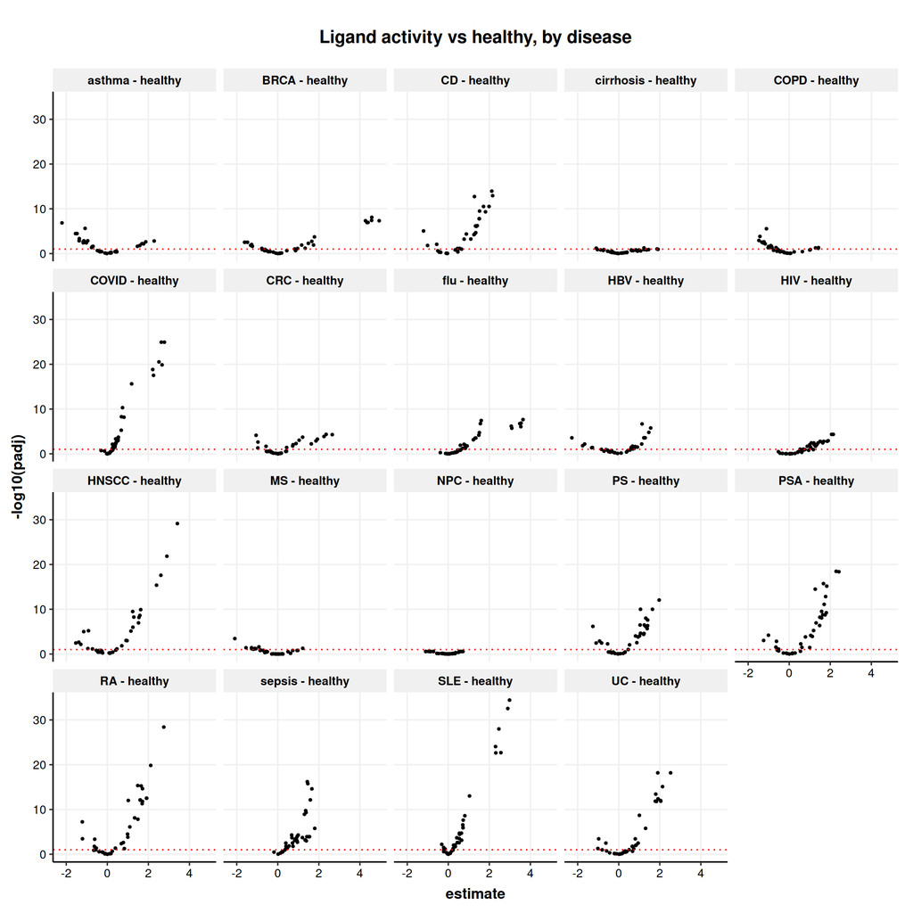

```r
res_disease %>%
  ggplot(aes(x = estimate, y = -log10(padj))) +
  geom_point(size = 0.8) +
  geom_hline(yintercept = 1, linetype = "dotted", color = "red") +
  facet_wrap(~contrast) +
  labs(title = "Ligand activity vs healthy, by disease")
```

# Celltype associations

## Naive vs non-naive (Level1, Tregs excluded)

```r
data_level1 <- atlas_level1 %>%
  mutate(across(c(disease, sex, chemistry, celltype), factor)) %>%
  drop_missing_age("celltype Level1")
```

```
## celltype Level1        dropping   0 of 1630 samples with no recorded binned age
```

```r
res_level1 <- fit_and_save(
  data_level1,
  rhs = "disease * celltype + sex + binned_age + chemistry",
  emm = ~ disease | celltype,
  contrast_args = list(method = "trt.vs.ctrl", ref = "healthy"),
  padj_by = c("contrast", "celltype"),
  name = "inflammation_atlas_celltype_level1"
)
```

```
## inflammation_atlas_celltype_level1: 1444 contrast x activity rows, 887 with padj < 0.1
```

## Fine celltypes (Level2)

`rg.limit` is raised because the disease x celltype reference grid is large.

```r
data_level2 <- atlas_level2 %>%
  mutate(across(c(disease, sex, chemistry, celltype), factor)) %>%
  drop_missing_age("celltype Level2")
```

```
## celltype Level2        dropping   0 of 8508 samples with no recorded binned age
```

```r
res_level2 <- fit_and_save(
  data_level2,
  rhs = "disease * celltype + sex + binned_age + chemistry",
  emm = ~ disease | celltype,
  contrast_args = list(method = "trt.vs.ctrl", ref = "healthy"),
  padj_by = c("contrast", "celltype"),
  name = "inflammation_atlas_celltype_level2",
  rg.limit = 20000
)
```

```
## inflammation_atlas_celltype_level2: 7942 contrast x activity rows, 4072 with padj < 0.1
```

```r
res_level2 %>%
  filter(padj < 0.1) %>%
  count(celltype, name = "significant_activity_contrasts") %>%
  arrange(desc(significant_activity_contrasts))
```

```
## # A tibble: 11 × 2
##    celltype        significant_activity_contrasts
##    <chr>                                    <int>
##  1 T_CD4_EM                                   438
##  2 Tregs                                      408
##  3 Th1                                        404
##  4 T_CD4_Naive                                400
##  5 Tregs_activated                            400
##  6 T_CD4_CM_ribo                              399
##  7 T_CD4_eff                                  350
##  8 T_CD4_CM                                   335
##  9 Th0                                        335
## 10 Th2                                        309
## 11 T_CD4_EMRA                                 294
```

Results are written to `analysis_outs/inference_model_disease_bulk/regressions/` and visualized in `08_viz_inflammation_atlas.Rmd`.